# Some exploration of Oxford Policy Response Database

Lio, Orestis

28 May, 2020

# 1 Defining a lockdown

The previous data source was defining a lockdown as:

> A lockdown is assumed when schools/universities and any non-essential businesses are closed.

In the case of Oxford this would imply when C1 & C2 are higher than 0. Not too bad. Canceling public events is not really a lock down and closing public transport is somewhat extreme (closer to what we would consider a …what’s the word?).

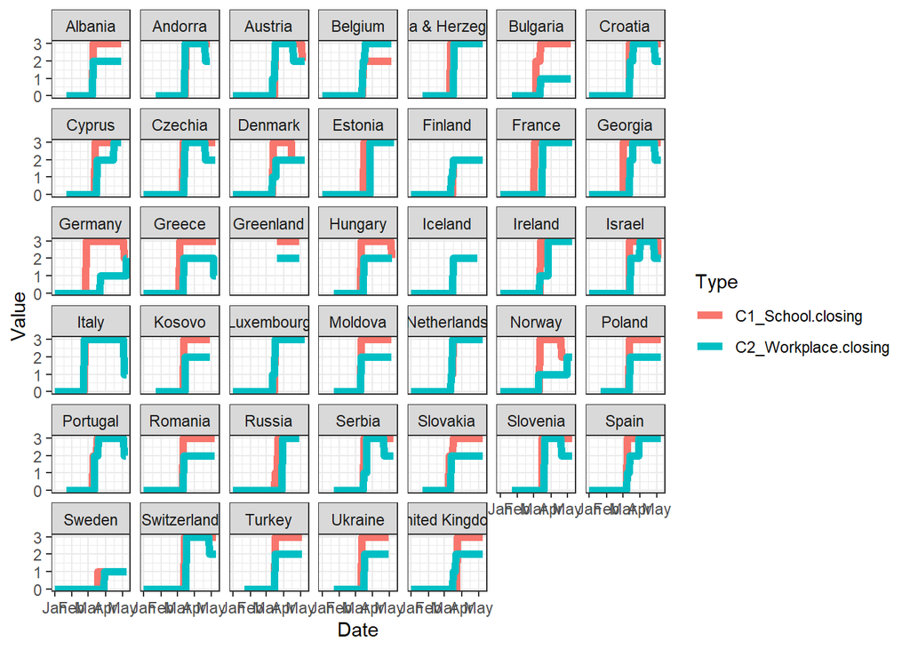

Figure 1.1: Lockdown=School&Workplace

Conveniently, in almost all European cases, the two measures are implemented simultaneously. But… By that criterion, every European country has gone into lockdown. Some countries earlier than others but still…not enough variation. I guess the intensity matters. Sweden for example scores 1 for both indexes. What does Oxford consider as C1=1 (C2=1)? Maybe we can raise the threshold to whatever score implies: CLOSED.

Let’s tighten up the criteria. What about staying at home?

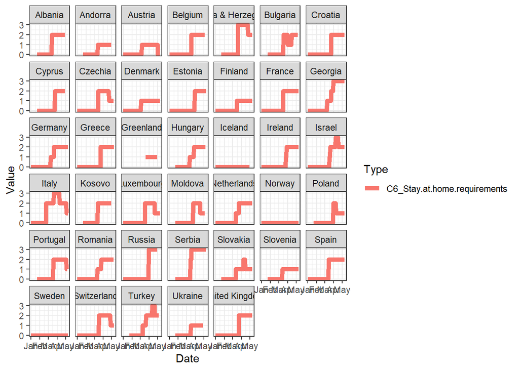

Figure 1.2: Lockdown=StayHome

This looks somewhat better. Iceland, Sweden and Norway did not bother. Belgium was late. Surprisingly, however, Greece is also portrayed to be late… Greece was among the strictest and first… Also, Spain and France does not appear to have reached a maximum score - like Italy did. This is also strange.

Did anyone close public transports?

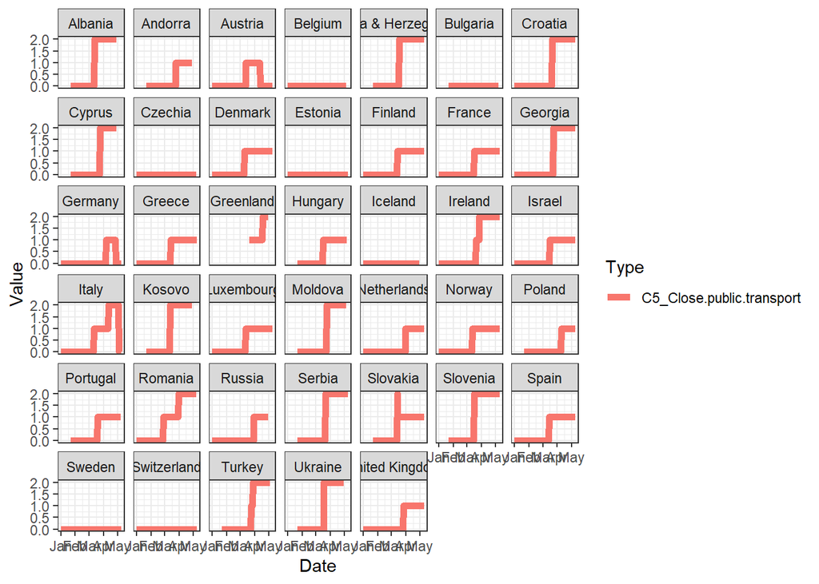

Figure 1.3: Lockdown=PublicTransp

Hard to make sense of this… Maybe someone who is not colourblind can help. We would like to pick the criteria for a lockdown according to:

1. Have interesting variation across countries: some implemented it, some didn’t
2. Have interesting variation for the duration in which it lasted
- the relaxation period is not yet accounted fully, this is captured mostly by the timing of the start
3. Make intuitive sense when telling the story

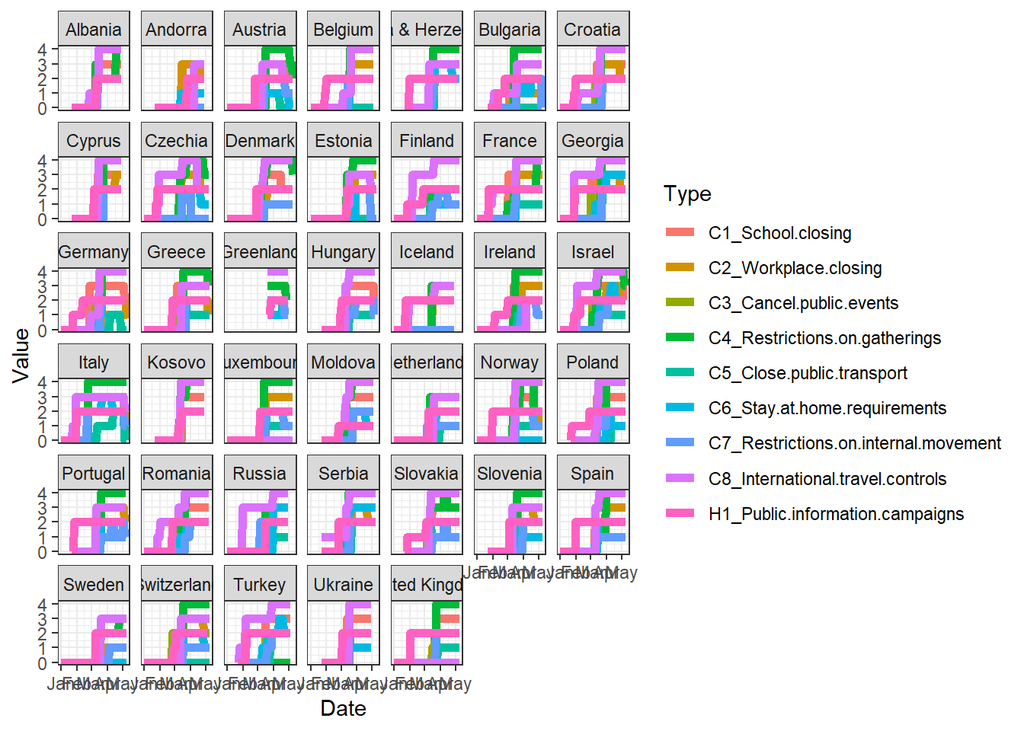

Figure 1.4: Lockdown=All